# Final Project

Will Jeffcott

02/02/2021

## Summary

In this R Markdown document I will investigate whether you can predict the manner in which exercise is carried out (classe variable) by looking at data from accelerometers on the belt, forearm, arm, and dumbell of 6 participants. I will do this using modelling techniques learned from the course.

### Data Train/Test/Validate

Let’s begin by loading the data which we will be using for the analysis.

```r
train <- read.csv('./pml-training.csv')
test <- read.csv('./pml-testing.csv')

dim(train)
```

```
## [1] 19622   160
```

We notice from a data print out that many of the variables have sizeable numbers of NA values. We don’t really want to model on a given variable if it is over 40% NAs. Let’s get rid of variables according to this principle:

```r
#gives a vector indicating the columns which we should remove
cols_to_remove <- sapply(train,function(x){ifelse(sum(is.na(x))>0.4*length(x),TRUE,FALSE)})
#now create a new data frame with the cols removed
train_rmv <- train[,!cols_to_remove]
dim(train_rmv)
```

```
## [1] 19622    93
```

This process vastly reduces the number of columns from 160 to 93. Now we notice that many of the columns have blank values rather than NAs. Adopting a similar strategy, let’s remove any variables from the set which are over 40% blank.

```r
#gives a vector indicating the columns which we should remove
cols_to_remove <- sapply(train_rmv,function(x){ifelse(sum(x == "")>0.4*length(x),TRUE,FALSE)})
#now create a new data frame with the cols removed
train_rmv_2 <- train_rmv[,!cols_to_remove]
```

This cuts us down again to 60 variables. Now let’s look for variables which have at least one NA or blank. We need an imputation strategy for dealing with these variables.

```r
cols_with_at_least_one_NA <- sapply(train_rmv_2,
                                    function(x){ifelse(sum(x == "" | is.na(x))>=1,TRUE,FALSE)})
sum(cols_with_at_least_one_NA)
```

```
## [1] 0
```

Since the resulting sum is zero we have no NAs or blanks in the dataset. Let’s now also remove any factors which we expect to not be very helpful. These factors include X, user_name, raw_timestamp_part_1, raw_timestamp_part_2, cvtd_timestamp (we are not doing a time related forecast and we do not want to keep user names)

```r
train_rmv_3 <- train_rmv_2[,!(colnames(train_rmv_2) %in% c('X',
                                                          'user_name',
                                                          'raw_timestamp_part_1',
                                                          'raw_timestamp_part_2',
                                                          'cvtd_timestamp'))]
```

### Principal Components Analysis

Many of the variables in our set may be virtually the same. Principal Components Analysis will allow us to decompose the vectors into a minimal set which explains most of the deviance. Let’s do this, with a threshold of 95%.

```r
library(caret)
preProc <- preProcess(train_rmv_3,method="pca",thresh=0.95)
train_pca <- predict(preProc,train_rmv_3)
dim(train_pca)
```

```
## [1] 19622    28
```

As we can see from the dim command, this further lowers our number of variables to just 28. Let’s train a model based on this dataset. Since we are trying to predict the ‘classe’ variable which has 5 levels, a decision tree might be a good place to start.

### Model Building and Cross Validation

## Decision Tree

Let’s start by building a decision tree on the 28 variables, using 10-fold cross validation. The cross validation allows us to select the average model performance out of 10 models against a validation set of 1/10th the size of the total train dataset.

```r
train_control<- trainControl(method="cv", number=10, savePredictions = "all")
rpart_fit <- train(classe ~ ., data=train_pca, trControl=train_control, method="rpart")
```

Let’s plot this decision tree to try and gauge what is going on:

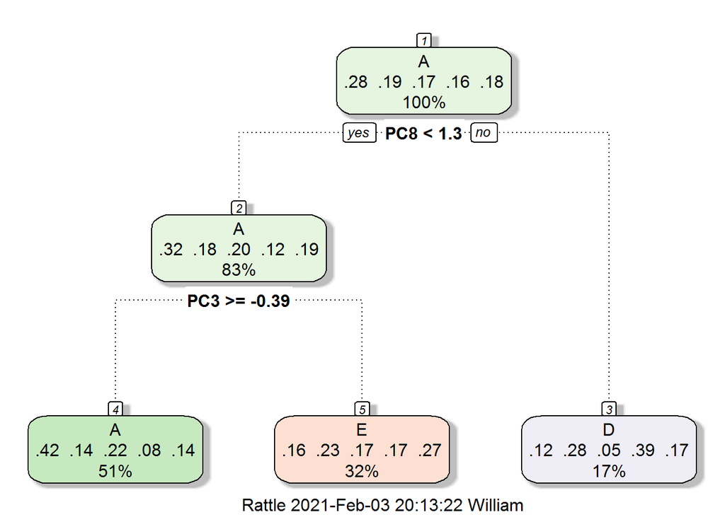

```r
library(rattle)
fancyRpartPlot(rpart_fit$finalModel)
```

Let’s also get a look at the accuracy of the model when predicting on the validation set.

```r
print(rpart_fit)
```

```
## CART
##
## 19622 samples
##    27 predictor
##     5 classes: 'A', 'B', 'C', 'D', 'E'
##
## No pre-processing
## Resampling: Cross-Validated (10 fold)
## Summary of sample sizes: 17661, 17658, 17660, 17662, 17660, 17660, ...
## Resampling results across tuning parameters:
##
##   cp          Accuracy   Kappa
##   0.04628970  0.3775349  0.18514249
##   0.04842615  0.3501090  0.13506050
##   0.06523287  0.3101159  0.05195217
##
## Accuracy was used to select the optimal model using the largest value.
## The final value used for the model was cp = 0.0462897.
```

A simple print out of the model shows that our best average model accuracy was only 37%. We can do far better than this!

## Random Forest

Let’s instead use a random forest with 5-fold cross validation. We perform this as follows:

```r
train_control<- trainControl(method="cv", number=5, savePredictions = "all")
rf_fit <- train(classe ~ ., data=train_pca, trControl=train_control, method="rf")
```

Whilst we can’t visualise the random forest in the same way as the decision tree, our print out shows improved accuracy for the best tuning parameters:

```r
print(rf_fit)
```

```
## Random Forest
##
## 19622 samples
##    27 predictor
##     5 classes: 'A', 'B', 'C', 'D', 'E'
##
## No pre-processing
## Resampling: Cross-Validated (5 fold)
## Summary of sample sizes: 15698, 15698, 15698, 15696, 15698
## Resampling results across tuning parameters:
##
##   mtry  Accuracy   Kappa
##    2    0.9811950  0.9762117
##   14    0.9791054  0.9735692
##   27    0.9754873  0.9689945
##
## Accuracy was used to select the optimal model using the largest value.
## The final value used for the model was mtry = 2.
```

## GBM

```r
print(gbm_fit)
```

```
## Stochastic Gradient Boosting
##
## 19622 samples
##    27 predictor
##     5 classes: 'A', 'B', 'C', 'D', 'E'
##
## No pre-processing
## Resampling: Cross-Validated (3 fold)
## Summary of sample sizes: 13082, 13082, 13080
## Resampling results across tuning parameters:
##
##   interaction.depth  n.trees  Accuracy   Kappa
##   1                   50      0.5735403  0.4529574
##   1                  100      0.6242489  0.5210834
##   1                  150      0.6480990  0.5527862
##   2                   50      0.6557948  0.5623961
##   2                  100      0.7190909  0.6437555
##   2                  150      0.7605239  0.6965406
##   3                   50      0.7111915  0.6334779
##   3                  100      0.7801445  0.7215010
##   3                  150      0.8221892  0.7749519
##
## Tuning parameter 'shrinkage' was held constant at a value of 0.1
##
## Tuning parameter 'n.minobsinnode' was held constant at a value of 10
## Accuracy was used to select the optimal model using the largest value.
## The final values used for the model were n.trees = 150, interaction.depth =
##  3, shrinkage = 0.1 and n.minobsinnode = 10.
```

We see that the GBM has a best accuracy of 82.2%. This is worse than the Random Forest

## Final Result

The best model that we trained on the data is the Random Forest. We will use this for our future 20 predictions of data.

We must first get the test dataset into the PCA format, and then use rf_fit to predict. Let’s do this as follows:

```r
test_pca <- predict(preProc,test)
test_predictions <- predict(rf_fit,test_pca)
```

Now let’s print our predictions:

```r
print(test_predictions)
```

```
##  [1] B A B A A E D B A A B C B A E E A B B B
## Levels: A B C D E
```